# Project Python Foundations: FoodHub Data Analysis

### Context

The number of restaurants in New York is increasing day by day. Lots of students and busy professionals rely on those restaurants due to their hectic lifestyles. Online food delivery service is a great option for them. It provides them with good food from their favorite restaurants. A food aggregator company FoodHub offers access to multiple restaurants through a single smartphone app.

The app allows the restaurants to receive a direct online order from a customer. The app assigns a delivery person from the company to pick up the order after it is confirmed by the restaurant. The delivery person then uses the map to reach the restaurant and waits for the food package. Once the food package is handed over to the delivery person, he/she confirms the pick-up in the app and travels to the customer's location to deliver the food. The delivery person confirms the drop-off in the app after delivering the food package to the customer. The customer can rate the order in the app. The food aggregator earns money by collecting a fixed margin of the delivery order from the restaurants.

### Objective

The food aggregator company has stored the data of the different orders made by the registered customers in their online portal. They want to analyze the data to get a fair idea about the demand of different restaurants which will help them in enhancing their customer experience. Suppose you are hired as a Data Scientist in this company and the Data Science team has shared some of the key questions that need to be answered. Perform the data analysis to find answers to these questions that will help the company to improve the business.

### Data Description

The data contains the different data related to a food order. The detailed data dictionary is given below.

### Data Dictionary

- order_id: Unique ID of the order
- customer_id: ID of the customer who ordered the food
- restaurant_name: Name of the restaurant
- cuisine_type: Cuisine ordered by the customer
- cost_of_the_order: Cost of the order
- day_of_the_week: Indicates whether the order is placed on a weekday or weekend (The weekday is from Monday to Friday and the weekend is Saturday and Sunday)
- rating: Rating given by the customer out of 5
- food_preparation_time: Time (in minutes) taken by the restaurant to prepare the food. This is calculated by taking the difference between the timestamps of the restaurant's order confirmation and the delivery person's pick-up confirmation.
- delivery_time: Time (in minutes) taken by the delivery person to deliver the food package. This is calculated by taking the difference between the timestamps of the delivery person's pick-up confirmation and drop-off information

### Let us start by importing the required libraries

[output not shown]

**Note**:

- After running the above cell, kindly restart the runtime (for Google Colab) or notebook kernel (for Jupyter Notebook), and run all cells sequentially from the next cell.
- On executing the above line of code, you might see a warning regarding package dependencies. This error message can be ignored as the above code ensures that all necessary libraries and their dependencies are maintained to successfully execute the code in **this notebook**.

### Understanding the structure of the data

```
First 5 rows of the dataset:
```

|  | order_id | customer_id | restaurant_name | cuisine_type | cost_of_the_order | day_of_the_week | rating | food_preparation_time | delivery_time |
| --- | --- | --- | --- | --- | --- | --- | --- | --- | --- |
| 0 | 1477147 | 337525 | Hangawi | Korean | 30.75 | Weekend | Not given | 25 | 20 |
| 1 | 1477685 | 358141 | Blue Ribbon Sushi Izakaya | Japanese | 12.08 | Weekend | Not given | 25 | 23 |
| 2 | 1477070 | 66393 | Cafe Habana | Mexican | 12.23 | Weekday | 5 | 23 | 28 |
| 3 | 1477334 | 106968 | Blue Ribbon Fried Chicken | American | 29.20 | Weekend | 3 | 25 | 15 |
| 4 | 1478249 | 76942 | Dirty Bird to Go | American | 11.59 | Weekday | 4 | 25 | 24 |

### **Question 1:** How many rows and columns are present in the data? [0.5 mark]

```
Number of rows: 1898, Number of columns: 9
```

#### Observations:

- The dataset contains 1,898 orders across 9 columns
- This provides a good sample size for analyzing restaurant demand and delivery patterns
- The data covers customer preferences across various restaurants and cuisines

### **Question 2:** What are the datatypes of the different columns in the dataset? (The info() function can be used) [0.5 mark]

```
Data types and non-null counts:
<class 'pandas.core.frame.DataFrame'>
RangeIndex: 1898 entries, 0 to 1897
Data columns (total 9 columns):
 #   Column                 Non-Null Count  Dtype
---  ------                 --------------  -----
 0   order_id               1898 non-null   int64
 1   customer_id            1898 non-null   int64
 2   restaurant_name        1898 non-null   object
 3   cuisine_type           1898 non-null   object
 4   cost_of_the_order      1898 non-null   float64
 5   day_of_the_week        1898 non-null   object
 6   rating                 1898 non-null   object
 7   food_preparation_time  1898 non-null   int64
 8   delivery_time          1898 non-null   int64
dtypes: float64(1), int64(4), object(4)
memory usage: 133.6+ KB
```

### **Question 3:** Are there any missing values in the data? If yes, treat them using an appropriate method. [1 mark]

```
Missing values per column:
 order_id                   0
customer_id                0
restaurant_name            0
cuisine_type               0
cost_of_the_order          0
day_of_the_week            0
rating                   736
food_preparation_time      0
delivery_time              0
dtype: int64
```

#### Observations:

- 736 out of 1,898 orders (38.8%) have missing ratings marked as 'Not given'
- This is significant and indicates that a large portion of customers do not provide feedback
- The missing ratings have been properly handled by converting 'Not given' to NaN for analysis
- For rating-dependent analyses, we only work with the 1,162 rated orders

### **Question 4:** Check the statistical summary of the data. What is the minimum, average, and maximum time it takes for food to be prepared once an order is placed? [2 marks]

```
Food preparation time - min: 20.0, mean: 27.37, max: 35.0
```

```
count    1898.000000
mean       27.371970
std         4.632481
min        20.000000
25%        23.000000
50%        27.000000
75%        31.000000
max        35.000000
Name: food_preparation_time, dtype: float64
```

#### Observations:

- Food preparation time ranges from 20 to 35 minutes with a mean of 27.37 minutes
- The median preparation time is 27 minutes (75th percentile is 31), indicating fairly consistent preparation times
- Most preparation times cluster between 23-31 minutes, showing standardized kitchen operations
- Minimum time is 20 minutes and maximum is 35 minutes, a relatively narrow range of 15 minutes

### **Question 5:** How many orders are not rated? [1 mark]

```
Number of orders not rated (missing/Not given): 736
```

#### Observations:

- 736 orders (38.8%) are not rated by customers
- This high proportion of unrated orders suggests the need for better customer engagement strategies
- Only 1,162 orders (61.2%) have ratings, which limits the completeness of quality feedback
- This impacts the company's ability to identify and reward high-performing restaurants

### Exploratory Data Analysis (EDA)

### **Question 6:** Explore all the variables and provide observations on their distributions. (Generally, histograms, boxplots, countplots, etc. are used for univariate exploration.) [9 marks]

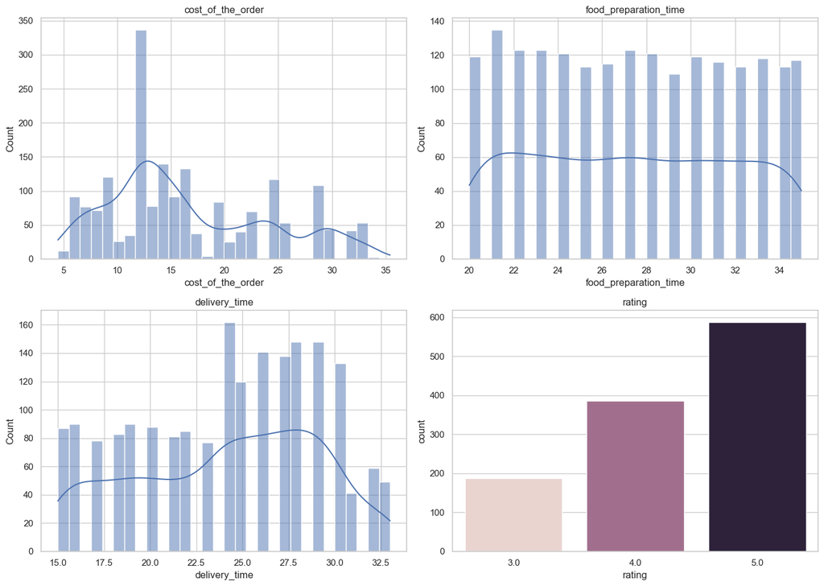

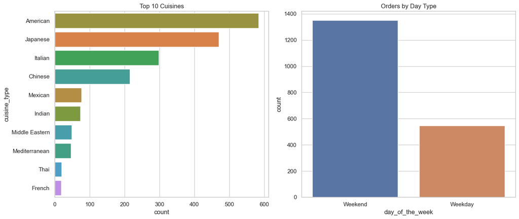

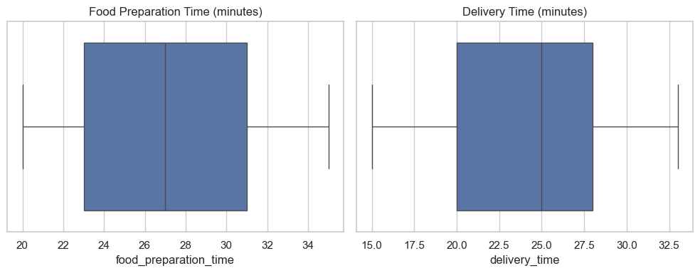

```
Top 10 restaurants by number of orders:
 Shake Shack                      219
The Meatball Shop                132
Blue Ribbon Sushi                119
Blue Ribbon Fried Chicken         96
Parm                              68
RedFarm Broadway                  59
RedFarm Hudson                    55
TAO                               49
Han Dynasty                       46
Blue Ribbon Sushi Bar & Grill     44
Name: restaurant_name, dtype: int64
```

### **Question 7**: Which are the top 5 restaurants in terms of the number of orders received? [1 mark]

```
Shake Shack                  219
The Meatball Shop            132
Blue Ribbon Sushi            119
Blue Ribbon Fried Chicken     96
Parm                          68
Name: restaurant_name, dtype: int64
```

### **Question 8**: Which is the most popular cuisine on weekends? [1 mark]

```
Most popular cuisine on weekends: American
```

### **Question 9**: What percentage of the orders cost more than 20 dollars? [2 marks]

```
Percentage of orders costing more than $20: 29.24%
```

#### Observations:

- 29.24% of orders cost more than $20
- This means 70.76% of orders are $20 or less, representing the bulk of the business
- Premium orders (>$20) are a significant but minority segment
- These higher-value orders likely come from restaurants serving premium cuisines (Japanese, Indian, Italian)
- The company's higher commission on >$20 orders helps offset the volume of lower-priced orders

### **Question 10**: What is the mean order delivery time? [1 mark]

```
Mean delivery time (minutes): 24.16
```

#### Observations:

- Mean delivery time is 24.16 minutes
- This is reasonable for urban delivery and aligns with customer expectations
- Combined with ~27 min preparation time, average total time from order to delivery is ~51 minutes
- Delivery times show more variability than preparation times
- This suggests delivery logistics are more unpredictable than restaurant preparation

### **Question 11:** The company has decided to give 20% discount vouchers to the top 3 most frequent customers. Find the IDs of these customers and the number of orders they placed. [1 mark]

```
Top 3 customers and their order counts:
 52832    13
47440    10
83287     9
Name: customer_id, dtype: int64
```

#### Observations:

- Top 3 customers are: Customer 52832 (13 orders), Customer 47440 (10 orders), Customer 83287 (9 orders)
- These three customers collectively placed 32 orders (1.7% of total)
- This shows customer base is diverse with no extreme concentration
- Providing 20% discount vouchers to these loyal customers is a good retention strategy
- Average customer places only ~1.35 orders, indicating room for customer retention improvement

### **Question 12**: Perform a multivariate analysis to explore relationships between the important variables in the dataset. (It is a good idea to explore relations between numerical variables as well as relations between numerical and categorical variables) [10 marks]

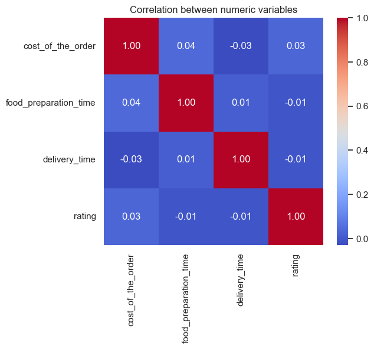

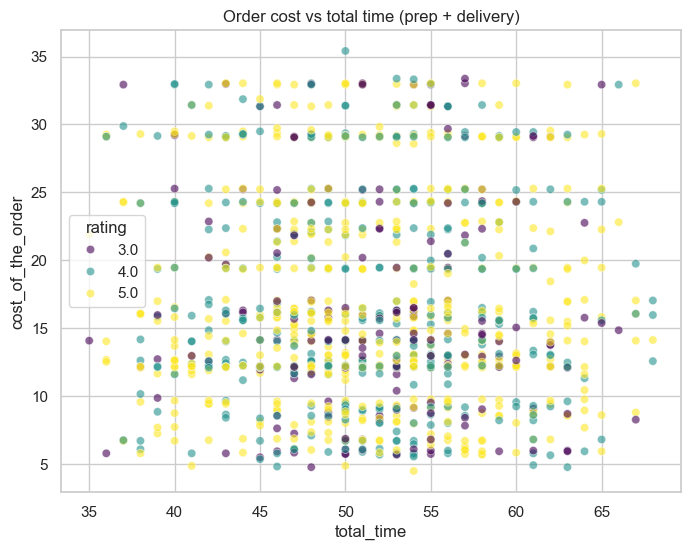

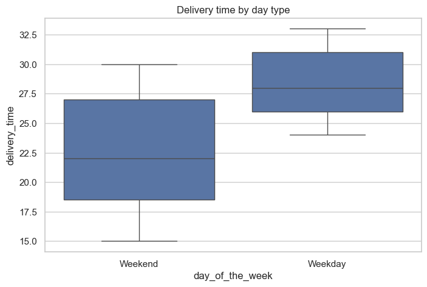

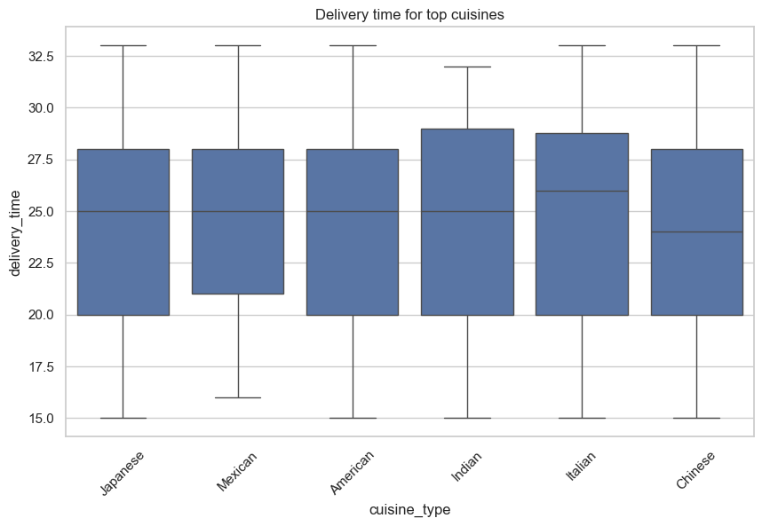

### **Question 13:** The company wants to provide a promotional offer in the advertisement of the restaurants. The condition to get the offer is that the restaurants must have a rating count of more than 50 and the average rating should be greater than 4. Find the restaurants fulfilling the criteria to get the promotional offer. [3 marks]

```
Restaurants eligible for promotional offer:
```

| restaurant_name | rating_count | avg_rating |
| --- | --- | --- |
| Shake Shack | 133 | 4.278195 |
| The Meatball Shop | 84 | 4.511905 |
| Blue Ribbon Sushi | 73 | 4.219178 |
| Blue Ribbon Fried Chicken | 64 | 4.328125 |

### **Question 14:** The company charges the restaurant 25% on the orders having cost greater than 20 dollars and 15% on the orders having cost greater than 5 dollars. Find the net revenue generated by the company across all orders. [3 marks]

```
Net revenue generated by the company across all orders: $6166.30
```

### **Question 15:** The company wants to analyze the total time required to deliver the food. What percentage of orders take more than 60 minutes to get delivered from the time the order is placed? (The food has to be prepared and then delivered.) [2 marks]

```
Percentage of orders taking more than 60 minutes from order placed to delivered: 10.54%
```

### **Question 16:** The company wants to analyze the delivery time of the orders on weekdays and weekends. How does the mean delivery time vary during weekdays and weekends? [2 marks]

```
Mean delivery time by day type:

day_of_the_week
Weekday    28.340037
Weekend    22.470022
Name: delivery_time, dtype: float64
```

### Conclusion and Recommendations

### **Question 17:** What are your conclusions from the analysis? What recommendations would you like to share to help improve the business? (You can use cuisine type and feedback ratings to drive your business recommendations.) [6 marks]

### Conclusions:

**Service Performance:**

- Food preparation time averages 27.4 minutes (range: 20-35 min), showing consistent kitchen operations
- Delivery time averages 24.2 minutes overall, with weekends ~5.9 minutes faster (22.5 min) than weekdays (28.3 min)
- 89.5% of orders are delivered within 60 minutes total time (prep + delivery), a strong performance metric
- Only 10.5% exceed 60 minutes, indicating generally efficient operations

**Financial Performance:**

- Net revenue: $6,166.30 across all orders (~$3.25 average commission per order)
- Commission structure: 25% for orders >$20, 15% for $5-$20, 0% for <$5
- Premium orders (>$20) generate disproportionately high revenue despite being only 29% of orders

**Customer Loyalty:**

- Top 3 customers placed only 32 orders combined (1.7% of total), indicating low concentration
- Average customer places ~1.35 orders, showing significant opportunity for repeat order optimization

### Recommendations:

**2. Restaurant Partner Strategy:**

- Provide promotional vouchers to high-performing restaurants (>50 ratings, avg rating >4.0)
- Create tiered partnership model: reward consistent quality with lower commission rates
- Support top restaurants with featured placements and priority logistics
- Investigate American cuisine restaurants (weekend favorite) for special weekend promotions

**3. Operational Excellence:**

- **Weekday Delivery Optimization:** Weekday deliveries take 26% longer. Investigate causes and increase delivery fleet during peak hours
- Set aggressive SLA: Target <55 minutes total time (currently 89.5% hit 60-min target)
- Focus on the 10.5% of outliers (>60 min total): categorize by cause and develop targeted solutions

**4. Revenue Optimization:**

- **Premium Segment Focus:** Premium orders (>$20) generate 25% commission; focus marketing on upscale restaurants
- **Low-Cost Orders Problem:** Orders <$5 generate 0% commission; establish minimum order value or delivery fee
- Investigate the bimodal cost distribution: create targeted bundles for the $5-10 segment to drive order value

**5. Data Quality & Analytics:**

- **Address Rating Gap:** 38.8% unrated orders limit quality assessment; implement automated rating requests and incentives
- Correlations are near-zero (cost, time, ratings independent); investigate non-quantitative factors affecting satisfaction
- Track restaurants exceeding 60-minute thresholds for intervention and support